# Practical Machine Learning Prediction Assignment

Melvin Yap

# Executive Summary

Given the training dataset, the objective of this assignment is to develop a predictive model for target variable **classe** that represents one of the 5 ways that the barbell lifts are performed by the participants. The model is then tested on the test dataset to determine its accuracy.

# Data Munging

The training and test datasets are first downloaded and loaded as data frames.

```r
library(RCurl)
urlTrain <- "https://d396qusza40orc.cloudfront.net/predmachlearn/pml-training.csv"
urlTest <- "https://d396qusza40orc.cloudfront.net/predmachlearn/pml-testing.csv"
x <- getURL(urlTrain)
y <- getURL(urlTest)
dfTrain <- as.data.frame(read.csv(textConnection(x)))
dfTest <- as.data.frame(read.csv(textConnection(y)))
```

```r
#Take note of the number of columns of the datasets
dim(dfTrain)
```

```
## [1] 19622   160
```

```r
dim(dfTest)
```

```
## [1]  20 160
```

Columns with near-zero variances are then removed as they are not only non-informative, but may also affect the accuracy of the model.

```r
library(caret)
nzv_cols <- nearZeroVar(dfTrain)
if(length(nzv_cols) > 0) dfTrain <- dfTrain[, -nzv_cols]
nzv_cols <- nearZeroVar(dfTest)
if(length(nzv_cols) > 0) dfTest <- dfTest[, -nzv_cols]
```

In addition, columns with irrelevant data, e.g. IDs, participant names and timestamps are removed from the dataset as they do not value-add to the predictive model. In both training and testing datasets, the first six columns have been identified to be irrelevant and are removed.

```r
dfTrain <- dfTrain[7:length(dfTrain)]
dfTest <- dfTest[7:length(dfTest)]
```

Lastly, columns with *NA* values are removed.

```r
trainNAs <- apply(dfTrain, 2, function(x) {sum(is.na(x))})
dfTrain <- dfTrain[,which(trainNAs == 0)]
testNAs <- apply(dfTest, 2, function(x) {sum(is.na(x))})
dfTest <- dfTest[,which(testNAs == 0)]
```

```r
#Take note of the trimmed number of columns of the datasets
dim(dfTrain)
```

```
## [1] 19622    53
```

```r
dim(dfTest)
```

```
## [1] 20 53
```

# Partitioning the Data

The training data is partitioned into both training (70%) and cross-validation (30%) datasets. The purpose of partitioning is to train the chosen model and validate it against the data it was not specifically fitted to in order to determine the model’s accuracy.

```r
set.seed(1234)
idxTrain <- createDataPartition(y=dfTrain$classe, p=0.7, list=F)
partTrain <- dfTrain[idxTrain,]
partValidate <- dfTrain[-idxTrain,]
```

# Model Development

## Selecting the Model

Random Forest is an ensemble of decision trees and is selected for its ability in finding a natural balance in biased datasets without much tuning, and yet produce fairly strong predictions.

## Fitting the Model

```r
library(randomForest)
modTrain <- randomForest(classe~., data=partTrain)
```

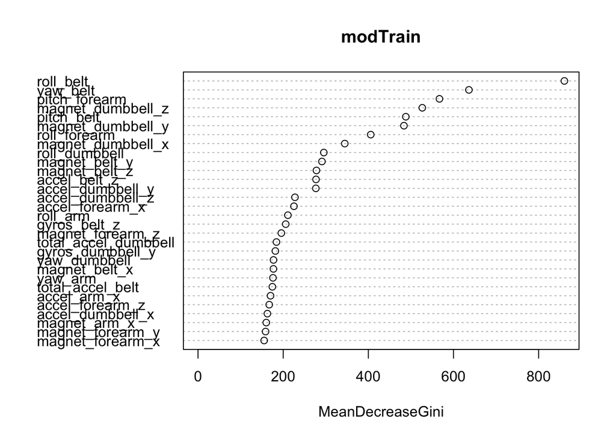

```r
varImpPlot(modTrain)
```

# Cross-Validation

The model is used to test against the 30% validation dataset, and the respective **classe** variables are compared to determine its accuracy.

```r
predictValidate <- predict(modTrain, partValidate)
conMatrix <- confusionMatrix(partValidate$classe, predictValidate)
conMatrix$overall
```

```
##       Accuracy          Kappa  AccuracyLower  AccuracyUpper   AccuracyNull
##      0.9966015      0.9957006      0.9947562      0.9979229      0.2858114
## AccuracyPValue  McnemarPValue
##      0.0000000            NaN
```

It is noted that the model has an accuracy of **99.66%** within the 95% confidence interval.

# Testing the Model

The model is now applied to the test dataset and the following prediction result is obtained, which fits the expected results of this assignment.

```r
predictTest <- predict(modTrain, dfTest)
predictTest #answers for submission of 20 files
```

```
##  1  2  3  4  5  6  7  8  9 10 11 12 13 14 15 16 17 18 19 20
##  B  A  B  A  A  E  D  B  A  A  B  C  B  A  E  E  A  B  B  B
## Levels: A B C D E
```